# The Effect of A Promotion Program on Sales and Customer Review Attitude For a Book Company

2023-02-20

## Get familar with the data

It is a data frame with **5000 observations** of **5 variables**.

There are five columns, date (character), user_submitted_review (character), title (character), total_purchased (integer) and customer type (character).

A brief look at the data:

- date : chr “2019-05-22” “2019-11-16” “2019-06-27” “2019-11-06” …
- user_submitted_review: chr “it was okay” “Awesome!” “Awesome!” “Awesome!” …
- title : chr “Secrets Of R For Advanced Students” “R For Dummies” “R For Dummies” “Fundamentals of R For Beginners” …
- total_purchased : int 7 3 1 3 NA 1 5 NA 7 1 …
- customer_type : chr “Business” “Business” “Individual” “Individual” …

There are **two** columns that have NA values.

- **User_submitted_review** column has 456 NA values
- **Total_purchased** column has 718 NA values

```r
getwd()
library(tidyverse)
library(readr)
raw<-read.csv("Part 1 sales2019.csv")
str(raw)
table(is.na(raw$date))
table(is.na(raw$user_submitted_review))
table(is.na(raw$title))
table(is.na(raw$total_purchased))
table(is.na(raw$customer_type))
```

## Handling the missing data

We’re going to remove any rows that have missing data in user_submitted_review and, for the total_purchased column, replace all of the NA values with an average value that we calculate from the complete dataset.

There are **4544 observations** left in the clean data frame.

```r
fillin<-mean(raw$total_purchased, na.rm = TRUE)
clean <- raw %>%
  filter(!is.na(user_submitted_review)) %>%
  mutate(new_total_purchased = if_else(is.na(total_purchased), fillin, total_purchased))

#print the first few rows to check
head(clean)
```

```
##         date    user_submitted_review                              title
## 1 2019-05-22              it was okay Secrets Of R For Advanced Students
## 2 2019-11-16                 Awesome!                      R For Dummies
## 3 2019-06-27                 Awesome!                      R For Dummies
## 4 2019-11-06                 Awesome!    Fundamentals of R For Beginners
## 5 2019-07-18                 Hated it    Fundamentals of R For Beginners
## 6 2019-01-28 Never read a better book Secrets Of R For Advanced Students
##   total_purchased customer_type new_total_purchased
## 1               7      Business            7.000000
## 2               3      Business            3.000000
## 3               1    Individual            1.000000
## 4               3    Individual            3.000000
## 5              NA      Business            4.009108
## 6               1      Business            1.000000
```

```r
table(is.na(clean$new_total_purchased))
```

```
##
## FALSE
##  4544
```

## Processing Review Data

I want to be able to classify reviews as either **positive, negative or neutral**. The comments are one of the followings:

- “Awesome!” (positive comment)
- “Never read a better book” (positive comment)
- “I learned a lot” (positive comment)
- “it was okay” (neutral comment)
- “OK” (neutral comment)
- “” (neutral comment)
- “Hated it” (negative comment)
- “The author’s other books were better” (negative comment)
- “A lot of material was not needed” (negative comment)
- “Would not recommend” (negative comment)

Based on the comment, I categorized the comments in a new column called “comment_attitude”.

```r
unique(clean$user_submitted_review)
```

```
##  [1] "it was okay"
##  [2] "Awesome!"
##  [3] "Hated it"
##  [4] "Never read a better book"
##  [5] "OK"
##  [6] "The author's other books were better"
##  [7] "A lot of material was not needed"
##  [8] ""
##  [9] "Would not recommend"
## [10] "I learned a lot"
```

```r
cleanreview <- clean %>%
  mutate(
    comment_attitude = case_when(
      user_submitted_review %in% c("it was okay", "OK", "") ~ "neutral comment",
      user_submitted_review %in% c("Awesome!", "Never read a better book", "I learned a lot") ~ "positive comment",
      TRUE ~ "negative comment"
    )
  )

head(cleanreview)
```

```
##         date    user_submitted_review                              title
## 1 2019-05-22              it was okay Secrets Of R For Advanced Students
## 2 2019-11-16                 Awesome!                      R For Dummies
## 3 2019-06-27                 Awesome!                      R For Dummies
## 4 2019-11-06                 Awesome!    Fundamentals of R For Beginners
## 5 2019-07-18                 Hated it    Fundamentals of R For Beginners
## 6 2019-01-28 Never read a better book Secrets Of R For Advanced Students
##   total_purchased customer_type new_total_purchased comment_attitude
## 1               7      Business            7.000000  neutral comment
## 2               3      Business            3.000000 positive comment
## 3               1    Individual            1.000000 positive comment
## 4               3    Individual            3.000000 positive comment
## 5              NA      Business            4.009108 negative comment
## 6               1      Business            1.000000 positive comment
```

## Comparing Book Sales Between Pre- and Post-Program Sales

The program started on July 1, 2019 and the data I have contains all of the sales for 2019. Here I will convert the date from string to a date, create a separate column, “before_after”, to distinguish the sales made before and after the program, and compare the sum of sales before and after the program was implemented.

```r
#conversion
cleanreview$date<-ymd(cleanreview$date)
str(cleanreview)
```

```
## 'data.frame':    4544 obs. of  7 variables:
##  $ date                 : Date, format: "2019-05-22" "2019-11-16" ...
##  $ user_submitted_review: chr  "it was okay" "Awesome!" "Awesome!" "Awesome!" ...
##  $ title                : chr  "Secrets Of R For Advanced Students" "R For Dummies" "R For Dummies" "Fundamentals of R For Beginners" ...
##  $ total_purchased      : int  7 3 1 3 NA 1 5 NA 7 1 ...
##  $ customer_type        : chr  "Business" "Business" "Individual" "Individual" ...
##  $ new_total_purchased  : num  7 3 1 3 4.01 ...
##  $ comment_attitude     : chr  "neutral comment" "positive comment" "positive comment" "positive comment" ...
```

```r
#separate column
clean_review_program<-cleanreview %>%
  mutate(before_after = ifelse(cleanreview$date>"2019-07-01","After","Before")
  )

#sum of sales before and after
sales_before_after<-clean_review_program %>%
  group_by(before_after) %>%
  summarize(
    books_purchased = sum(new_total_purchased)
  )
sales_before_after
```

```
## # A tibble: 2 × 2
##   before_after books_purchased
##   <chr>                  <dbl>
## 1 After                  9051.
## 2 Before                 9141.
```

There were around **9141 purchases made before the program** and around **9051 made after the program**. Just by this number, it seems that the program even harmed the number of sales a little.

I would like to divide the purchases by customer type in the next step.

## Book Sales Within Customer Type Before and After the Program

Here is the summary of numbers of books purchased before and after program by both business and individuals.

```r
clean_review_program_customer<-clean_review_program %>%
  group_by(before_after, customer_type) %>%
  summarize(
    books_purchased = sum(new_total_purchased)
  )
clean_review_program_customer
```

```
## # A tibble: 4 × 3
## # Groups:   before_after [2]
##   before_after customer_type books_purchased
##   <chr>        <chr>                   <dbl>
## 1 After        Business                6300.
## 2 After        Individual              2751.
## 3 Before       Business                6235.
## 4 Before       Individual              2906.
```

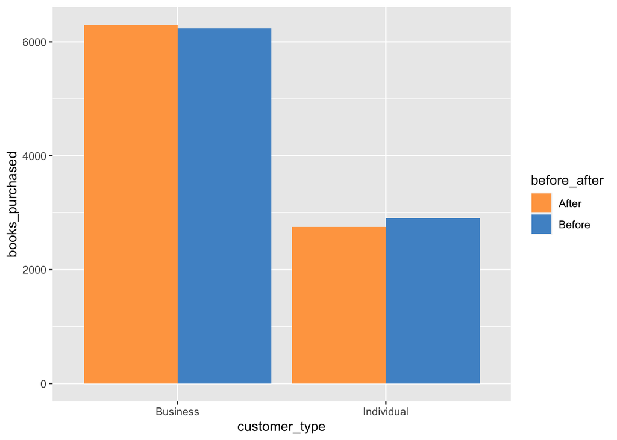

```r
ggplot(clean_review_program_customer, aes(x=customer_type, y=books_purchased, fill=before_after)) +
  geom_bar(stat="identity", position="dodge") +
  scale_fill_manual(values = c("tan1", "steelblue3"))
```

## Review Attitude Before and After the Program

```r
review <- clean_review_program %>%
  group_by(before_after) %>%
  summarize(
    num_positive_reviews = sum(comment_attitude == "positive comment"),
    num_neutral_review = sum(comment_attitude == "neutral comment"),
    num_negative_review = sum(comment_attitude == "negative comment")
  )
review
```

```
## # A tibble: 2 × 4
##   before_after num_positive_reviews num_neutral_review num_negative_review
##   <chr>                       <int>              <int>               <int>
## 1 After                         682                660                 935
## 2 Before                        660                689                 918
```

## Conclusion

The goal was to find out how effective the program was. After looking at the effect that it had on the sales overall, I believe we can conclude that **it wasn’t an effective program.** Although there was a slight change between its effect on business customers and individual customers, without m a hypothesis test, I cannot confirm that the difference between business and individual customers’ reactions is significant or the difference between the sales data before and after the program to confirm is significant.